# NDVI projection results

Cara Gallagher

2024-01-17

So I tried a few different model formulations based on our chat the other day and came up with two options.

Model 1:

```r
model1 <- lmer(meanNDVI ~ pr + pr^2 + rsdt + tasmin + tasmin^2 + (pr | site) + (tasmin | site) + (1 | year),
                      data = NDVI_GCM_dat_scaled,
                      REML = FALSE,
                      control = lmerControl(optimizer = "bobyqa"))
```

This required another optimizer (bobyqa) to converge and I set REML to FALSE because I was getting the error “boundary (singular) fit”.

Output details for this model:

```
## Linear mixed model fit by maximum likelihood  ['lmerMod']
## Formula: meanNDVI ~ pr + pr^2 + rsdt + tasmin + tasmin^2 + (pr | site) +
##     (tasmin | site) + (1 | year)
##    Data: NDVI_GCM_dat_scaled
## Control: lmerControl(optimizer = "bobyqa")
##
##      AIC      BIC   logLik deviance df.resid
## -19763.7 -19668.6   9893.8 -19787.7    20436
##
## Scaled residuals:
##     Min      1Q  Median      3Q     Max
## -4.5120 -0.4376  0.1204  0.5852  4.3230
##
## Random effects:
##  Groups   Name        Variance  Std.Dev. Corr
##  year     (Intercept) 0.0003935 0.01984
##  site     (Intercept) 0.0021180 0.04602
##           tasmin      0.0048782 0.06984  -0.99
##  site.1   (Intercept) 0.0049958 0.07068
##           pr          0.0004921 0.02218  -0.02
##  Residual             0.0220169 0.14838
## Number of obs: 20448, groups:  year, 23; site, 10
##
## Fixed effects:
##             Estimate Std. Error t value
## (Intercept) 0.521827   0.027029  19.306
## pr          0.024649   0.007185   3.431
## rsdt        0.074449   0.001579  47.140
## tasmin      0.126117   0.022174   5.688
##
## Correlation of Fixed Effects:
##        (Intr) pr     rsdt
## pr     -0.012
## rsdt   -0.002 -0.011
## tasmin -0.531  0.000 -0.060
```

The second model is just a simpler version, without the polynomials:

Model 2:

```r
model2 <- lmer(meanNDVI ~ pr + rsdt + tasmin + (1 | site) + (1 | year), data = NDVI_GCM_dat_scaled)
```

Output details for this model:

```
## Linear mixed model fit by REML ['lmerMod']
## Formula: meanNDVI ~ pr + rsdt + tasmin + (1 | site) + (1 | year)
##    Data: NDVI_GCM_dat_scaled
##
## REML criterion at convergence: -17340.6
##
## Scaled residuals:
##     Min      1Q  Median      3Q     Max
## -4.0902 -0.5595  0.1345  0.6607  3.5596
##
## Random effects:
##  Groups   Name        Variance  Std.Dev.
##  year     (Intercept) 0.0003676 0.01917
##  site     (Intercept) 0.0087458 0.09352
##  Residual             0.0248812 0.15774
## Number of obs: 20448, groups:  year, 23; site, 10
##
## Fixed effects:
##             Estimate Std. Error t value
## (Intercept) 0.498530   0.029865   16.69
## pr          0.022360   0.001191   18.77
## rsdt        0.072437   0.001656   43.75
## tasmin      0.141249   0.001888   74.82
##
## Correlation of Fixed Effects:
##        (Intr) pr     rsdt
## pr      0.000
## rsdt   -0.001  0.001
## tasmin  0.001  0.012 -0.719
```

I thought it could be nice to compare the last 10 years of the empirical NDVI data (as colored points) to the first 10 years of data from the projections (grey violins) to get an idea if these make sense. Both overall seem to fit the data much nicer than the original super basic model I was using, though “Model 1” seems to fit the variability in the higher latitude sites a bit better, but is worse at some of the intermediate sites (like Havelaue).  
Model 1:

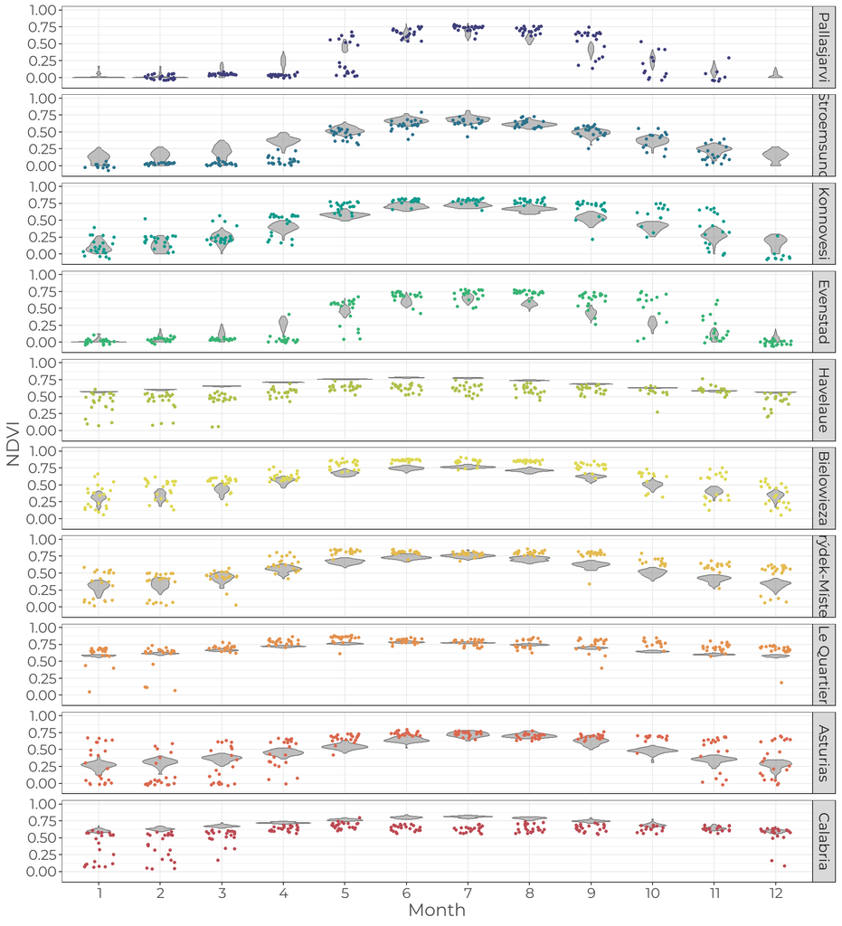

Model 2:

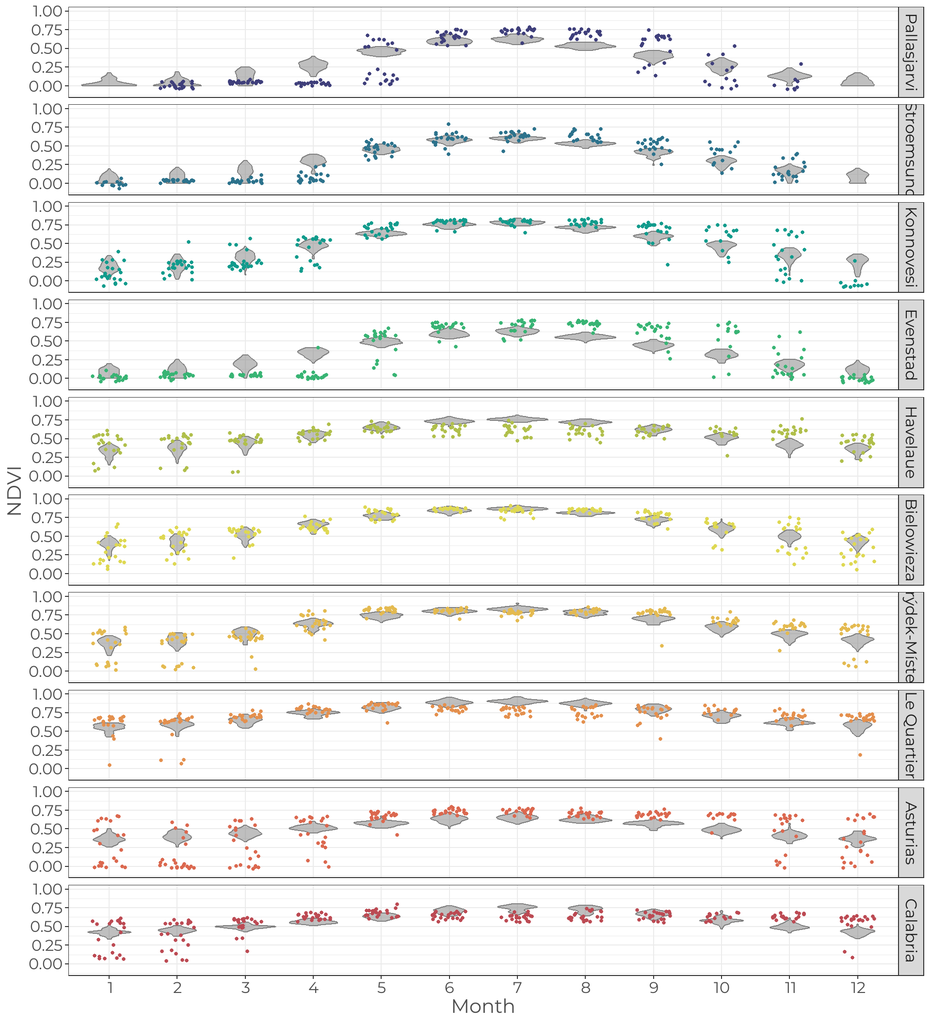

When looking at the outputs for the whole projection period, both predict overall increases in NDVI.  
Model 1:

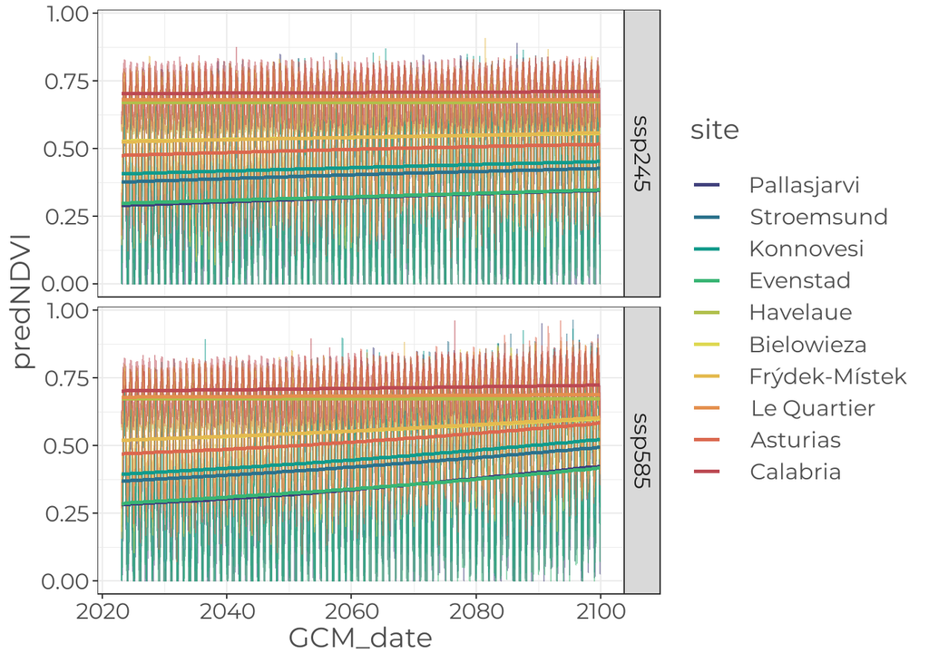

Model 2:

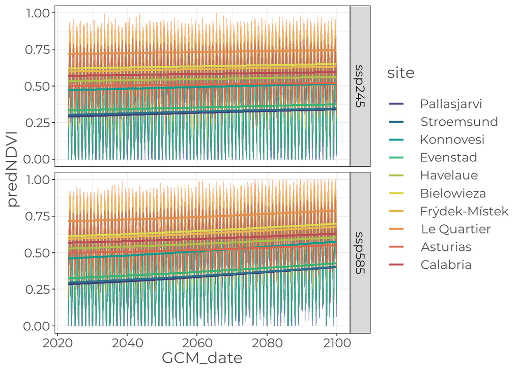

But when filtering the data to look at specific months, it seems like some interesting things are going on in Model 1 with sites getting more similar under the higher climate change emissions scenario in July and increases primarily occurring in northern sites in January.  
Model 1:

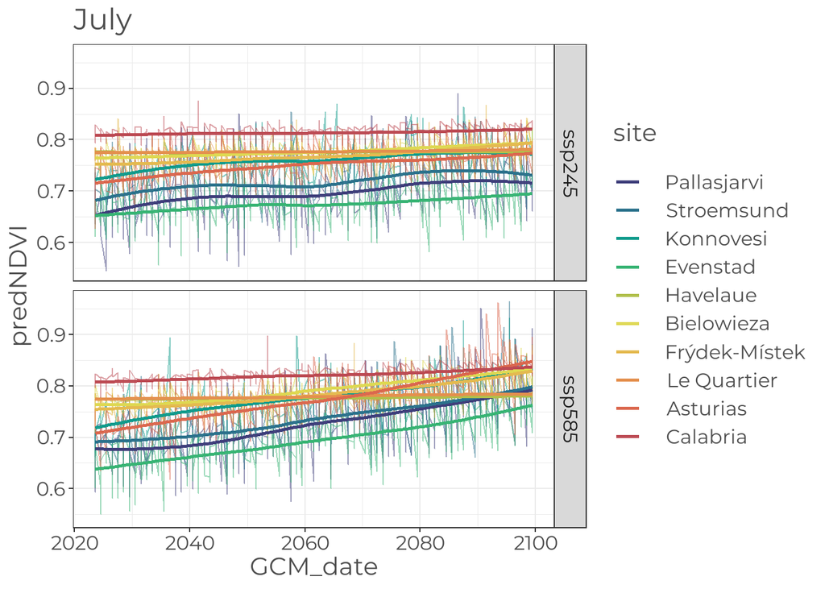

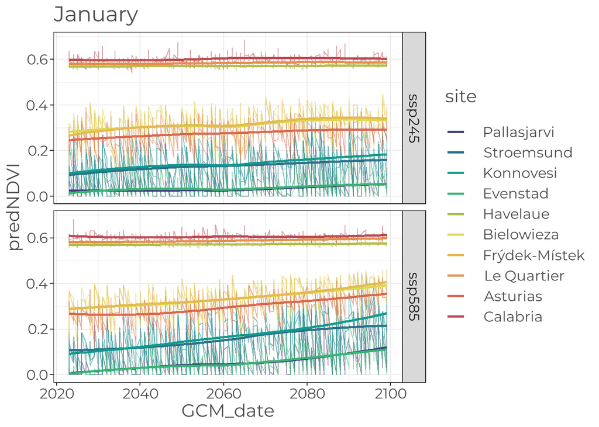

While in model 2, it looks like all sites increase under both emissions scenarios and months.  
Model 2:

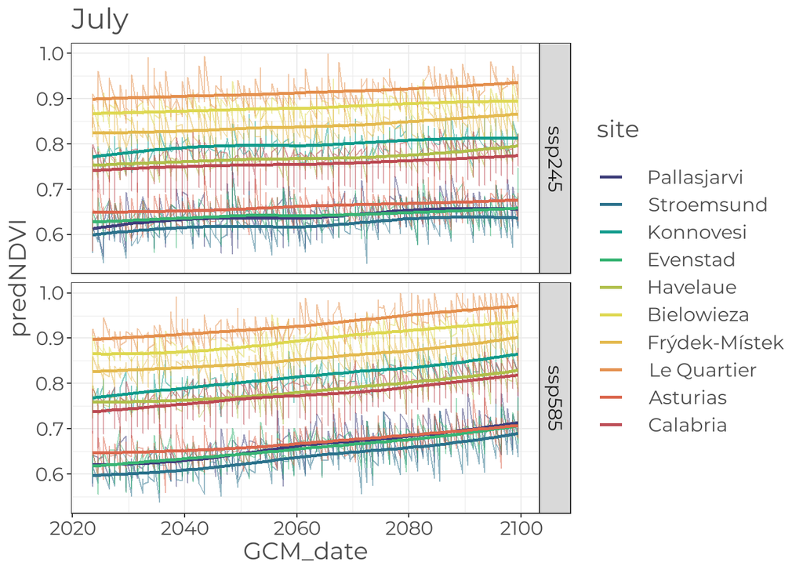

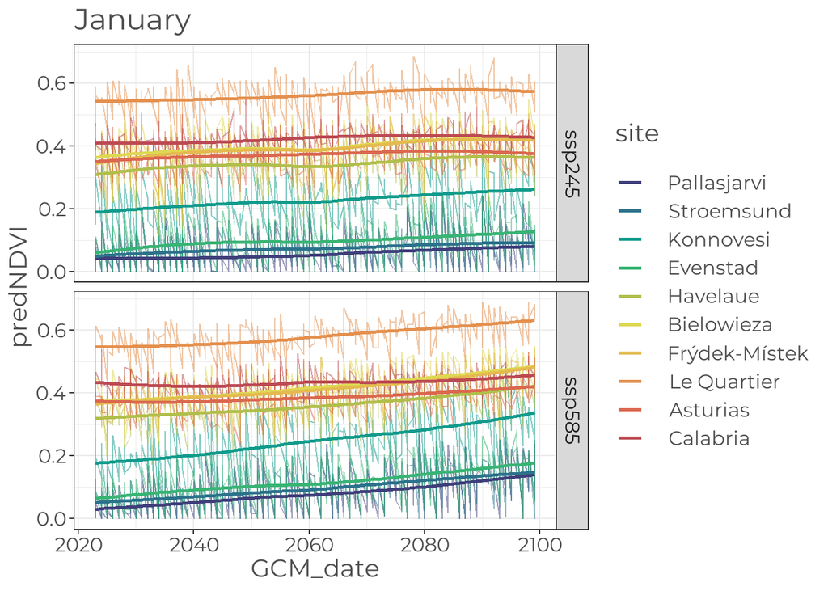